# ESM 244 HW 3

## Task 3

### Mapping California National Parks

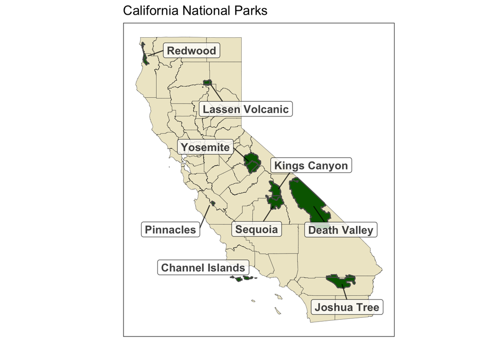

```r
# Read in CA counties shapefile and set crs to WGS84:

ca_counties <- read_sf(".", layer = "california_county_shape_file")
st_crs(ca_counties) = 4326


# Read in NPS data and set crs to WGS84:
ca_nps <- read_sf(".", layer = "nps_boundary") %>%
  filter(STATE == "CA", UNIT_TYPE == "National Park") %>%
  dplyr::select(UNIT_NAME, PARKNAME) %>%
  mutate(lon=map_dbl(geometry, ~st_centroid(.x)[[1]]),
         lat=map_dbl(geometry, ~st_centroid(.x)[[2]]))

st_crs(ca_nps) = 4326

# Change NA value for ParkName to Redwoods
ca_nps[is.na(ca_nps)]<-"Redwood"

# Clip off the Nevada part of Death Valley National Park
nps_clip <- st_intersection(ca_nps, ca_counties)

# CA National Parks graph:
ggplot(ca_counties) +
  geom_sf(fill = "cornsilk2",
          color  = "grey10",
          size =  0.1) +
  geom_sf(data = nps_clip, fill= "darkgreen") +
  geom_label_repel(data=ca_nps, aes(x=lon, y=lat, label=PARKNAME),
                  box.padding = 0.80,
                  point.padding = 0.5,
                  alpha = 0.75,
                  fontface = 'bold',
                  color = 'black') +
  theme_bw() +
  theme(panel.grid.major = element_line(colour = 'transparent'),
        axis.text.x = element_blank(),
        axis.text.y = element_blank(),
        axis.ticks = element_blank()) +
  labs(x = "", y = "",
       title = "California National Parks")
```

## Task 4

### Lizards in the Northern Chihuahuan Desert

1. For all lizards trapped at site ‘CALI’, do weights of male and female adult lizards differ significantly?

```r
# Read in data set filter for adult male and female lizards at site 'CALI' (use for both tests)
lizard <- read_csv("lizard_clean.csv") %>%
  filter(site == "CALI") %>%
  filter(sex == "M" | sex == "F") %>%
  replace_with_na_all(condition = ~.x == ".")

# Make weights numeric
lizard$weight <- as.numeric(lizard$weight)

# Subset data for just male only and female only to visualize distributions

lizard_male <- lizard %>%
  filter(sex == "M", weight != "NA")

lizard_female <- lizard %>%
  filter(sex == "F", weight != "NA")


# Visualize distributions with histograms

#ggplot(lizard_male, aes(x=weight)) +
  #geom_histogram()

#ggplot(lizard_female, aes(x=weight)) +
  #geom_histogram()

# Both are skewed but sample sizes are over 30 so CLT says means will be evenly distributed

########## Hypothesis Testing ###############
# Run F-test for equal variances
# HO: Variances are equal (ratio of variances = 1)
# HA: Variances are not equal (ratio of variances ≠ 1)
lizard_ftest <- var.test(weight ~ sex, data = lizard)

# Results - retain the null (p-value = 0.2938) variances are equal

# Run an upaired t-test to determine if weights are significantly different between males and females:
# H0: Mean weights are equal
# HA: Mean weights are not equal
lizard_ttest <- t.test(weight ~ sex, data = lizard, var.equal = TRUE)

# Results - Mean weights are not significantly different t(130) = 0.79647; p-value = 0.4272

# Actual mean weights
male_mean <- mean(lizard_male$weight) # 4.965
male_sd <- sd(lizard_male$weight) #5.679
female_mean <- mean(lizard_female$weight) # 5.826
female_sd <- sd(lizard_female$weight) #6.496

# Difference in mean weights:
mean_diff <- female_mean - male_mean
#0.862

#Effect size Cohen's D:
lizard_eff <- cohen.d(weight ~ sex, data = lizard)
# Negligible Cohens D = -0.14
```

Mean adult female lizard (5.83 g ± 6.50 g, n = 75) and male lizard (4.97 g ± 5.68 g, n = 57) body mass did not differ significantly [t(130) = 0.8, *p* = 0.427, $\alpha$ = 0.05] and the actual difference in mean weight between female and male lizards is less than one gram with a negligible effect size (Cohen’s D = -0.14).

2. For lizards trapped at the ‘CALI’ site, is there a significant difference in the proportion of adult male and female lizards with broken tails?

```r
# Chi square to test for differences in proportions
#H0 - there is no difference in proportion of males and females with broken tails
#HA - there IS a difference in proportion of males and females with broken tails

lizard_chi <- lizard %>%
  dplyr::select(sex, tail) %>%
  filter(tail != "NA") %>%
  count(sex, tail) %>%
  spread(tail, n) %>%
  dplyr::select(-sex)

row.names(lizard_chi) <- c("F", "M")

#Perform chi-square

lizard_x2test <- chisq.test(lizard_chi)

# NOT a significant difference in proportions X2(1) = 0.30857, p-value = 0.5786

# Proportions for reporting:
# Total male - 56
# Total female - 77
male_broken <- 10/56 #0.179
female_broken <- 18/77 #0.234
```

There is not a significant difference in the proportion of adult male (0.18) and female (0.23) lizards with broken tails [$x^2$ = (1) = 0.31, *p* = 0.579].